# State-Space models in the mvgam package

Nicholas J Clark

2023-09-07

The purpose of this vignette is to show how the `mvgam` package can be used to fit and interrogate State-Space models with nonlinear effects.

## State-Space Models

[figure not shown]

Illustration of a basic State-Space model, which assumes that a latent dynamic *process* (X) can evolve independently from the way we take *observations* (Y) of that process

State-Space models allow us to separately make inferences about the underlying dynamic *process model* that we are interested in (i.e. the evolution of a time series or a collection of time series) and the *observation model* (i.e. the way that we survey / measure this underlying process). This is extremely useful in ecology because our observations are always imperfect / noisy measurements of the thing we are interested in measuring. It is also helpful because we often know that some covariates will impact our ability to measure accurately (i.e. we cannot take accurate counts of rodents if there is a thunderstorm happening) while other covariate impact the underlying process (it is highly unlikely that rodent abundance responds to one storm, but instead probably responds to longer-term weather and climate variation). A State-Space model allows us to model both components in a single unified modelling framework. A major advantage of `mvgam` is that it can include nonlinear effects and random effects in BOTH model components while also capturing dynamic processes.

### Lake Washington plankton data

The data we will use to illustrate how we can fit State-Space models in `mvgam` are from a long-term monitoring study of plankton counts (cells per mL) taken from Lake Washington in Washington, USA. The data are available as part of the `MARSS` package and can be downloaded using the following:

```r
load(url('https://github.com/atsa-es/MARSS/raw/master/data/lakeWAplankton.rda'))
```

We will work with five different groups of plankton:

```r
outcomes <- c('Greens', 'Bluegreens', 'Diatoms', 'Unicells', 'Other.algae')
```

As usual, preparing the data into the correct format for `mvgam` modelling takes a little bit of wrangling in `dplyr`:

```r
# loop across each plankton group to create the long datframe
plankton_data <- do.call(rbind, lapply(outcomes, function(x){

  # create a group-specific dataframe with counts labelled 'y'
  # and the group name in the 'series' variable
  data.frame(year = lakeWAplanktonTrans[, 'Year'],
             month = lakeWAplanktonTrans[, 'Month'],
             y = lakeWAplanktonTrans[, x],
             series = x,
             temp = lakeWAplanktonTrans[, 'Temp'])})) %>%

  # change the 'series' label to a factor
  dplyr::mutate(series = factor(series)) %>%

  # filter to only include some years in the data
  dplyr::filter(year >= 1965 & year < 1975) %>%
  dplyr::arrange(year, month) %>%
  dplyr::group_by(series) %>%

  # z-score the counts so they are approximately standard normal
  dplyr::mutate(y = as.vector(scale(y))) %>%

  # add the time indicator
  dplyr::mutate(time = dplyr::row_number()) %>%
  dplyr::ungroup()
```

Inspect the data structure

```r
head(plankton_data)
```

```
## # A tibble: 6 × 6
##    year month       y series       temp  time
##   <dbl> <dbl>   <dbl> <fct>       <dbl> <int>
## 1  1965     1 -0.542  Greens      -1.23     1
## 2  1965     1 -0.344  Bluegreens  -1.23     1
## 3  1965     1 -0.0768 Diatoms     -1.23     1
## 4  1965     1 -1.52   Unicells    -1.23     1
## 5  1965     1 -0.491  Other.algae -1.23     1
## 6  1965     2 NA      Greens      -1.32     2
```

```r
dplyr::glimpse(plankton_data)
```

```
## Rows: 600
## Columns: 6
## $ year   <dbl> 1965, 1965, 1965, 1965, 1965, 1965, 1965, 1965, 1965, 1965, 196…
## $ month  <dbl> 1, 1, 1, 1, 1, 2, 2, 2, 2, 2, 3, 3, 3, 3, 3, 4, 4, 4, 4, 4, 5, …
## $ y      <dbl> -0.54241769, -0.34410776, -0.07684901, -1.52243490, -0.49055442…
## $ series <fct> Greens, Bluegreens, Diatoms, Unicells, Other.algae, Greens, Blu…
## $ temp   <dbl> -1.2306562, -1.2306562, -1.2306562, -1.2306562, -1.2306562, -1.…
## $ time   <int> 1, 1, 1, 1, 1, 2, 2, 2, 2, 2, 3, 3, 3, 3, 3, 4, 4, 4, 4, 4, 5, …
```

Note that we have z-scored the counts in this example as that will make it easier to specify priors (though this is not completely necessary; it is often better to build a model that respects the properties of the actual outcome variables)

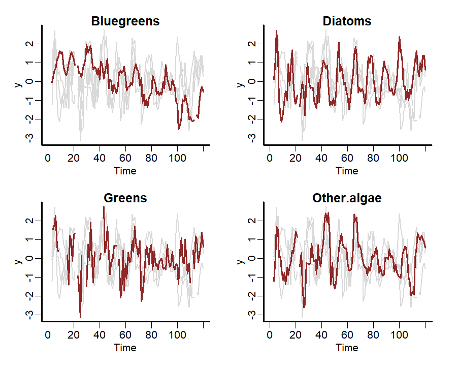

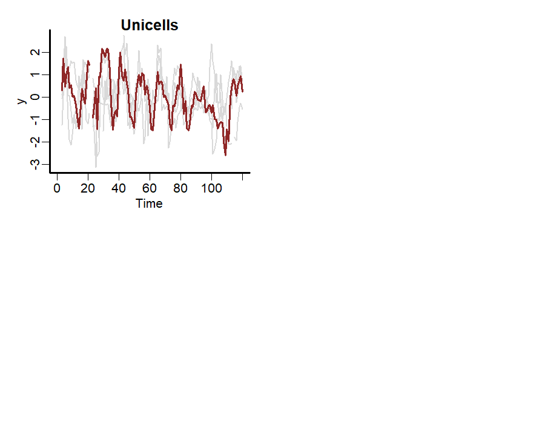

```r
plot_mvgam_series(data = plankton_data, series = 'all')
```

As usual, check the data for `NA`s:

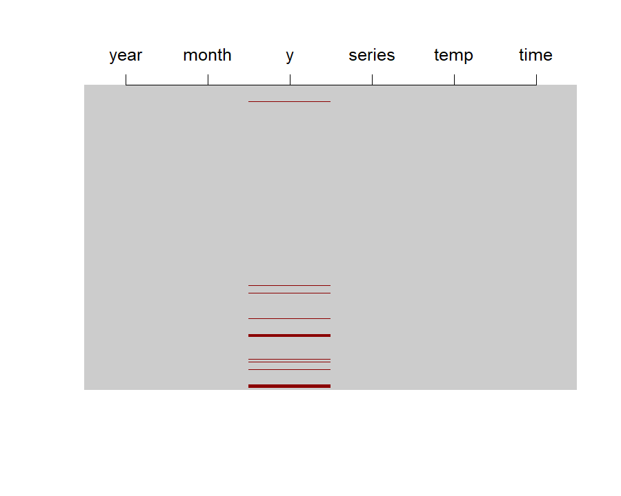

```r
image(is.na(t(plankton_data)), axes = F,
      col = c('grey80', 'darkred'))
axis(3, at = seq(0,1, len = NCOL(plankton_data)),
     labels = colnames(plankton_data))
```

We have some missing observations, but of course this isn’t an issue for modelling in `mvgam`. A useful property to understand about these counts is that they tend to be highly seasonal. Below are some plots of z-scored counts against the z-scored temperature measurements in the lake for each month:

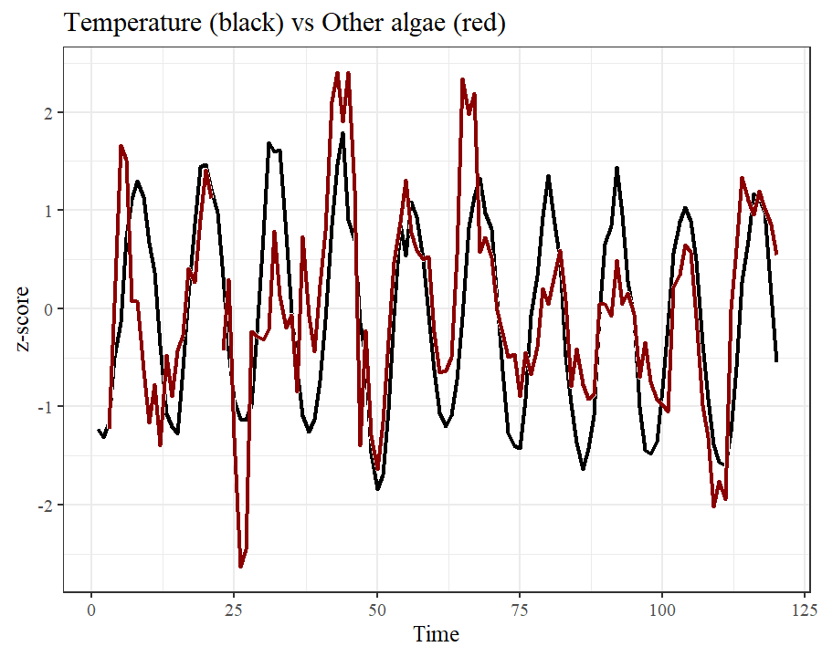

```r
plankton_data %>%
  dplyr::filter(series == 'Other.algae') %>%
  ggplot(aes(x = time, y = temp)) +
  geom_line(size = 1.1) +
  geom_line(aes(y = y), col = 'white',
            size = 1.3) +
  geom_line(aes(y = y), col = 'darkred',
            size = 1.1) +
  ylab('z-score') +
  xlab('Time') +
  ggtitle('Temperature (black) vs Other algae (red)')
```

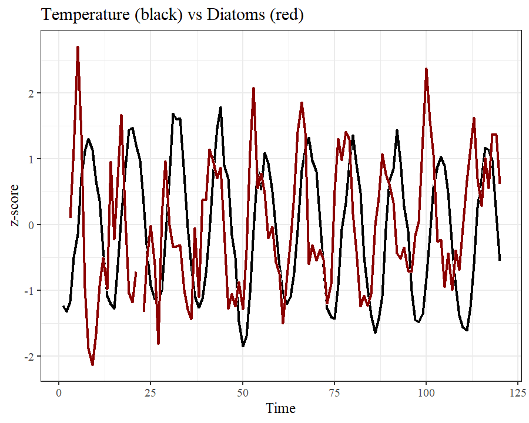

```r
plankton_data %>%
  dplyr::filter(series == 'Diatoms') %>%
  ggplot(aes(x = time, y = temp)) +
  geom_line(size = 1.1) +
  geom_line(aes(y = y), col = 'white',
            size = 1.3) +
  geom_line(aes(y = y), col = 'darkred',
            size = 1.1) +
  ylab('z-score') +
  xlab('Time') +
  ggtitle('Temperature (black) vs Diatoms (red)')
```

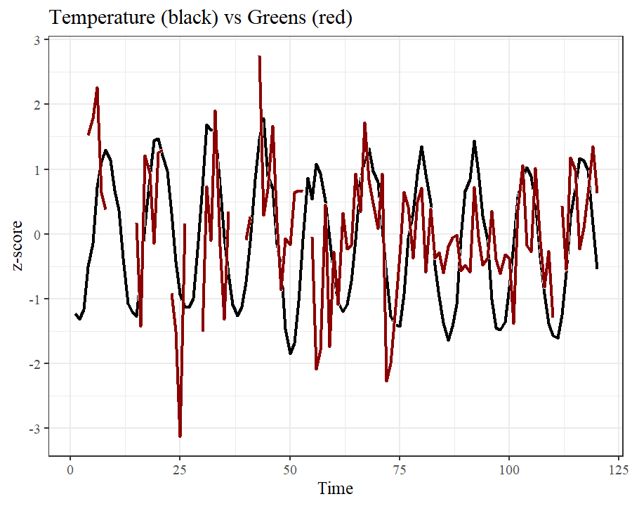

```r
plankton_data %>%
  dplyr::filter(series == 'Greens') %>%
  ggplot(aes(x = time, y = temp)) +
  geom_line(size = 1.1) +
  geom_line(aes(y = y), col = 'white',
            size = 1.3) +
  geom_line(aes(y = y), col = 'darkred',
            size = 1.1) +
  ylab('z-score') +
  xlab('Time') +
  ggtitle('Temperature (black) vs Greens (red)')
```

We will have to try and capture this seasonality in our process model, which should be easy to do given the flexibility of GAMs. Next we will split the data into training and testing splits:

```r
plankton_train <- plankton_data %>%
  dplyr::filter(time <= 112)
plankton_test <- plankton_data %>%
  dplyr::filter(time > 112)
```

Now time to fit some models. This requires a bit of thinking about how we can best tackle the seasonal variation and the likely dependence structure in the data. These algae are interacting as part of a complex system within the same lake, so we certainly expect there to be some lagged cross-dependencies underling their dynamics. But if we do not capture the seasonal variation, our multivariate dynamic model will be forced to try and capture it, which could lead to poor convergence and unstable results (we could feasibly capture cyclic dynamics with a more complex multi-species Lotka-Volterra model, but ordinary differential equation approaches are beyond the scope of this workshop).

### Capturing seasonality

```r
notrend_mod <- mvgam(y ~
                       # tensor of temp and month to capture
                       # "global" seasonality
                       te(temp, month, k = c(4, 4)) +

                       # series-specific deviation tensor products
                       te(temp, month, k = c(4, 4), by = series),
                     family = gaussian(),
                     data = plankton_train,
                     newdata = plankton_test,
                     trend_model = 'None')
```

The “global” tensor product smooth function can be quickly visualized:

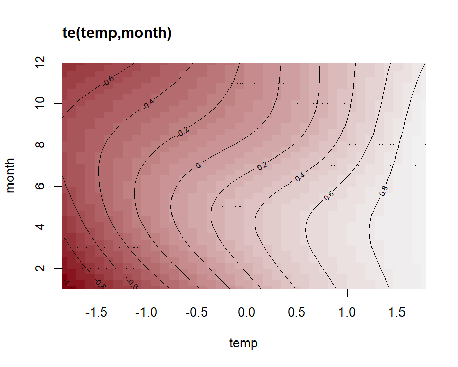

```r
plot_mvgam_smooth(notrend_mod, smooth = 1)
```

We can then plot the deviation smooths for each algal group to see how they vary from the “global” pattern:

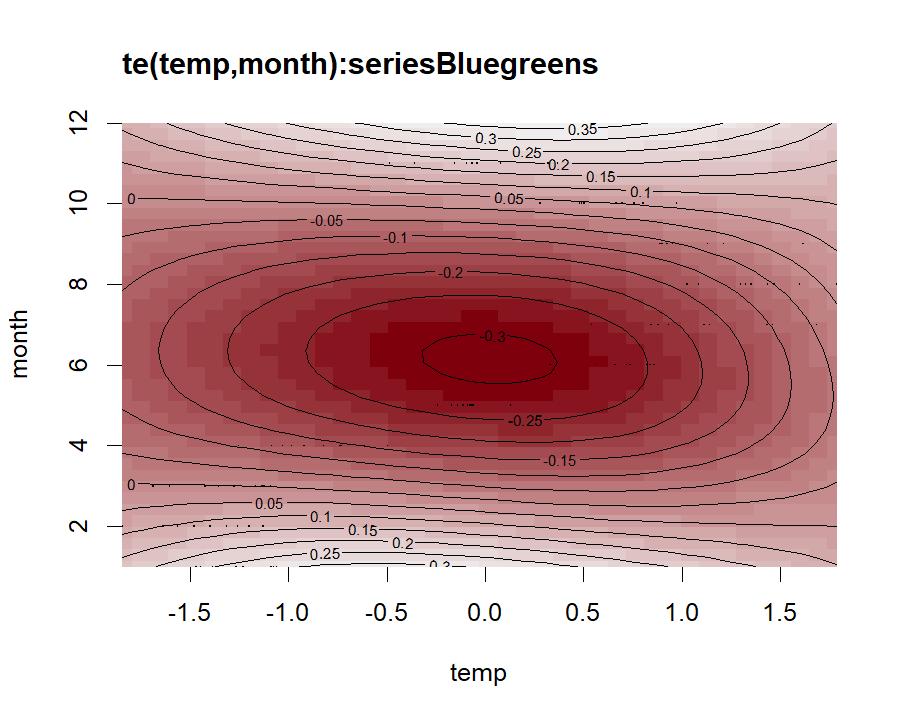

```r
plot_mvgam_smooth(notrend_mod, smooth = 2)
```

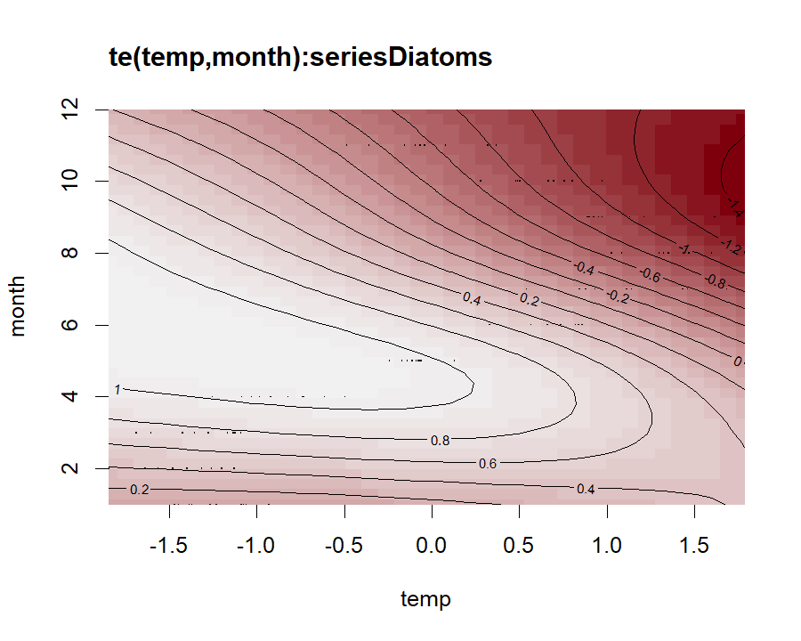

```r
plot_mvgam_smooth(notrend_mod, smooth = 3)
```

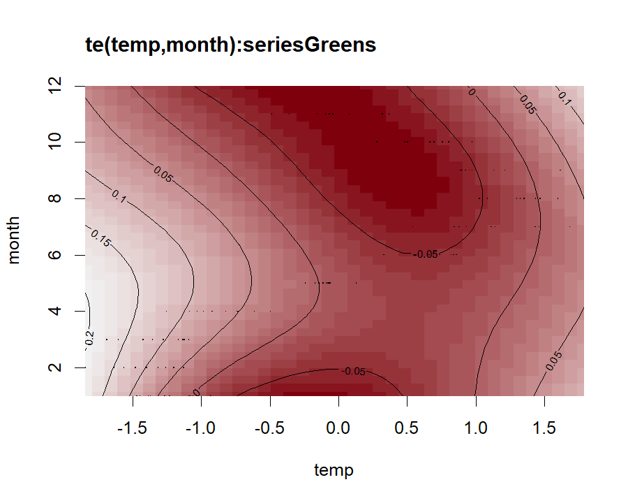

```r
plot_mvgam_smooth(notrend_mod, smooth = 4)
```

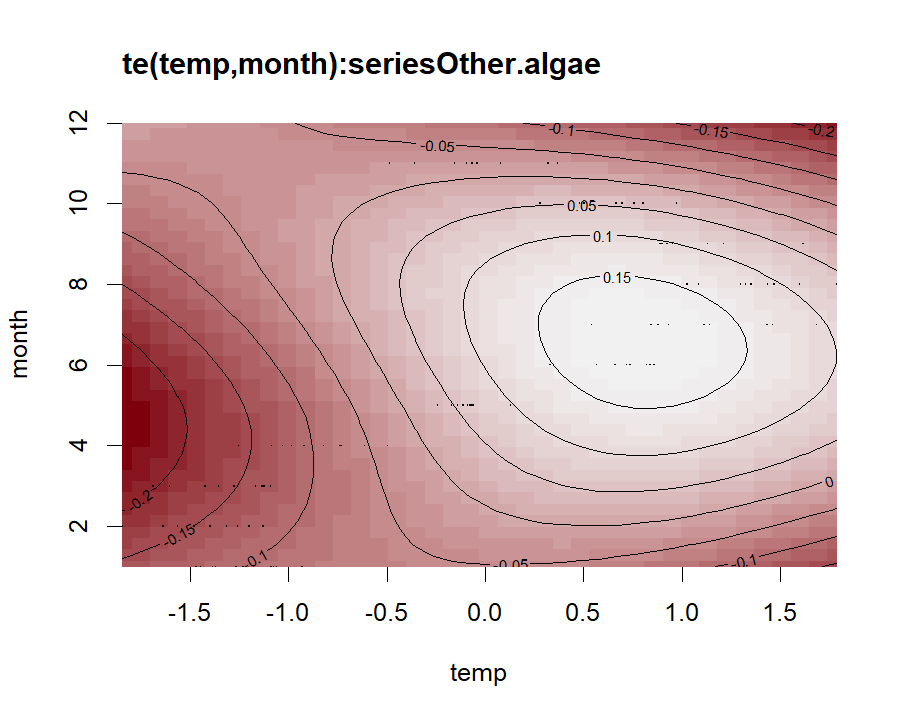

```r
plot_mvgam_smooth(notrend_mod, smooth = 5)
```

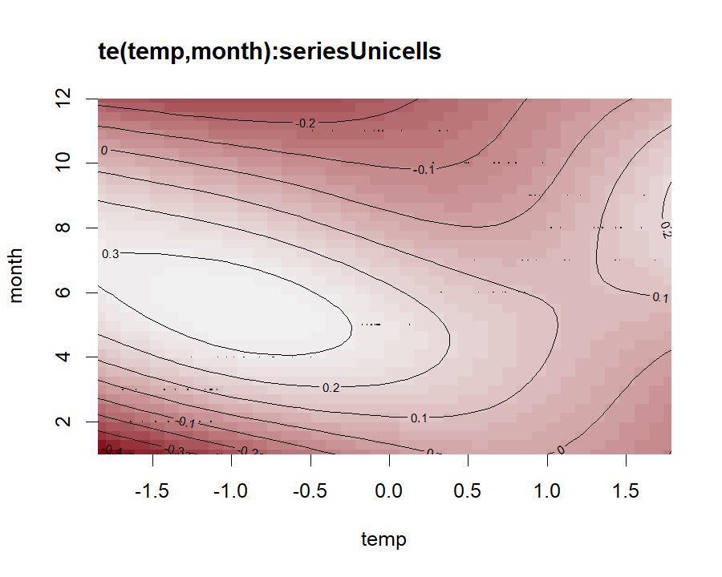

```r
plot_mvgam_smooth(notrend_mod, smooth = 6)
```

These multidimensional smooths have done a good job of capturing the seasonal variation in our observations:

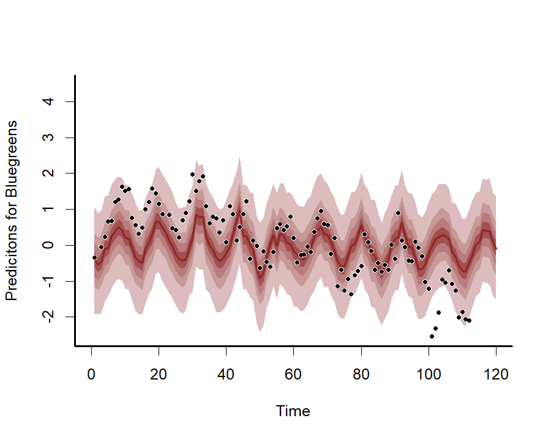

```r
plot(notrend_mod, type = 'forecast', series = 1)
```

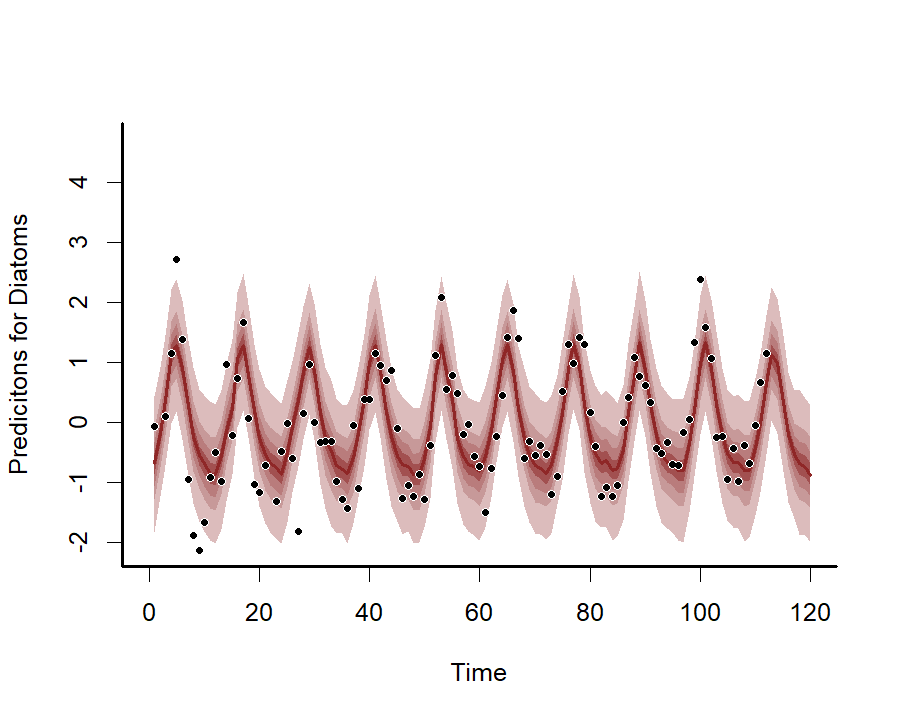

```r
plot(notrend_mod, type = 'forecast', series = 2)
```

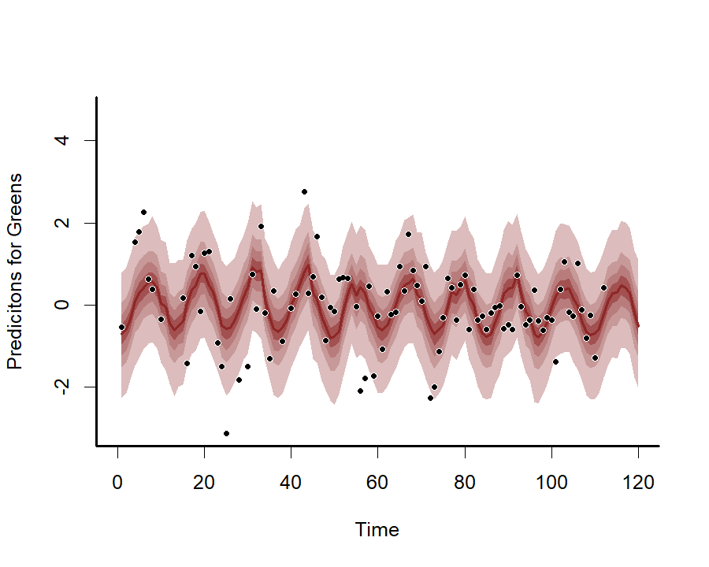

```r
plot(notrend_mod, type = 'forecast', series = 3)
```

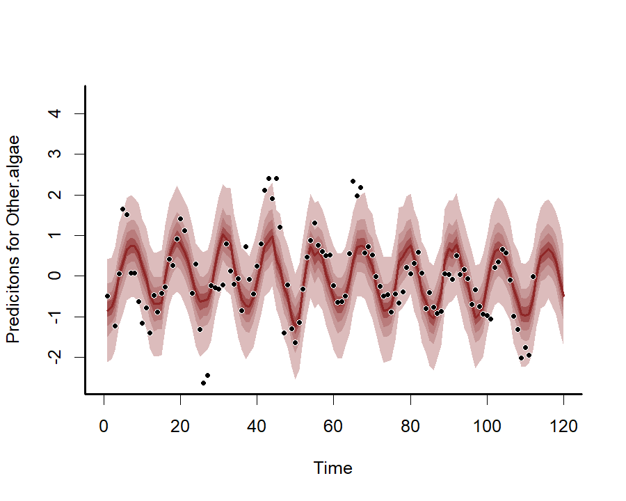

```r
plot(notrend_mod, type = 'forecast', series = 4)
```

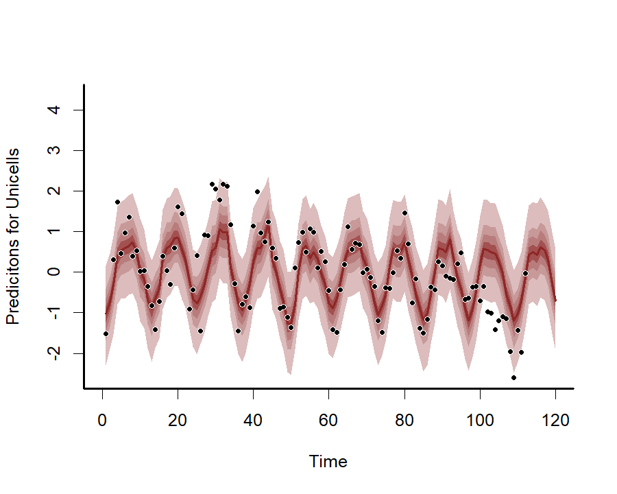

```r
plot(notrend_mod, type = 'forecast', series = 5)
```

### Multiseries dynamics

The basic model gives us confidence that we can capture the seasonal variation in the observations. But the model has not captured the remaining temporal dynamics, which is obvious when we inspect Dunn-Smyth residuals for each series:

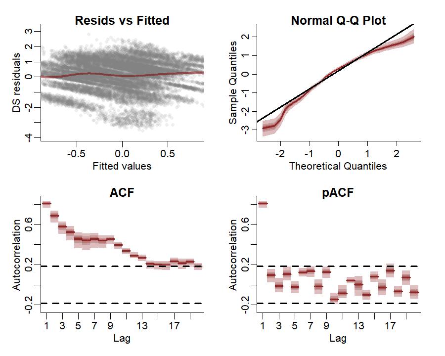

```r
plot(notrend_mod, type = 'residuals', series = 1)
```

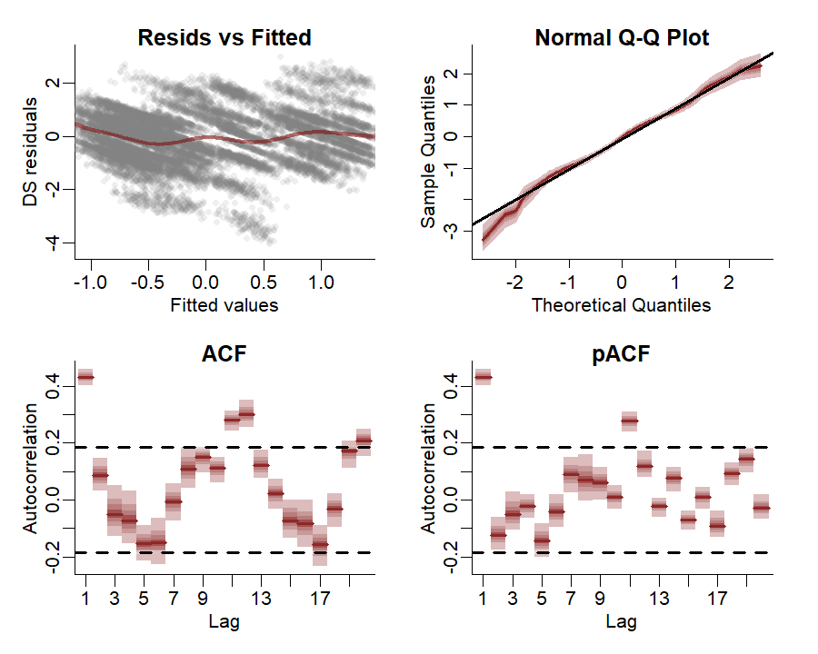

```r
plot(notrend_mod, type = 'residuals', series = 2)
```

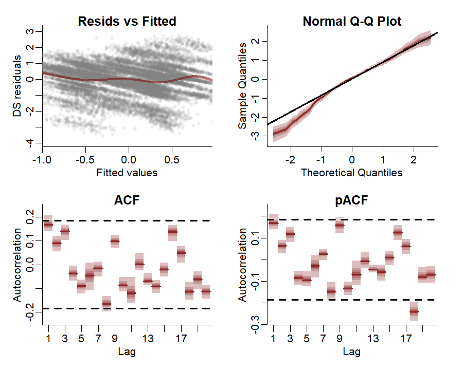

```r
plot(notrend_mod, type = 'residuals', series = 3)
```

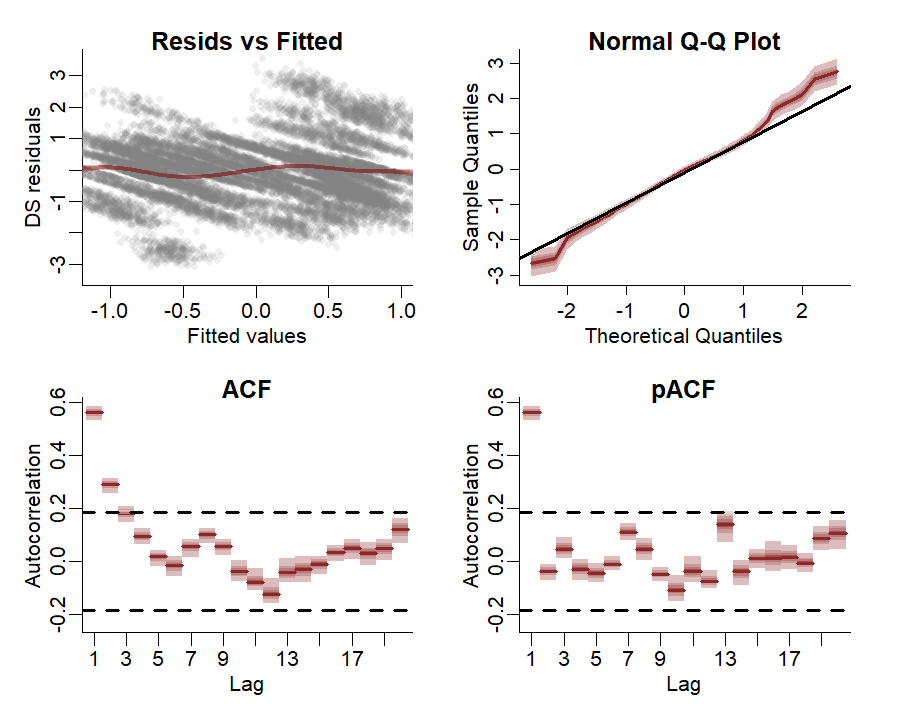

```r
plot(notrend_mod, type = 'residuals', series = 4)
```

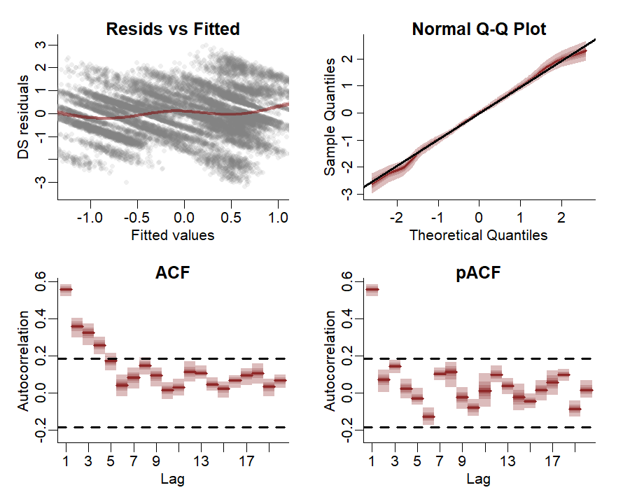

```r
plot(notrend_mod, type = 'residuals', series = 5)
```

Now it is time to get into multivariate State-Space models. We will fit two models that can both incorporate lagged cross-dependencies in the latent process models. The first model assumes that the process errors operate independnetly from one another, while the second assumes that there may be contemporaneous correlations in the process errors. Both models include a Vector Autoregressive component for the process means, and so both can model complex community dynamics. The models can be described mathematically as follows:

$$\begin{align*}
\boldsymbol{count}_t & \sim \text{Normal}(\mu_{obs[t]},
\sigma_{obs}) \\
\mu_{obs[t]} & = \alpha + process_t \\
\sigma_{obs} & \sim \text{Uniform}(0.1, 1) \\
process_t & \sim \text{MVNormal}(\mu_{process[t]}, \Sigma_{process})
\\
\mu_{process[t]} & = VAR * process_{t-1} +
f_{global}(\boldsymbol{month},\boldsymbol{temp})_t +
f_{series}(\boldsymbol{month},\boldsymbol{temp})_t \\
f_{global}(\boldsymbol{month},\boldsymbol{temp}) & =
\sum_{k=1}^{K}b_{global} * \beta_{global} \\
f_{series}(\boldsymbol{month},\boldsymbol{temp}) & =
\sum_{k=1}^{K}b_{series} * \beta_{series} \\
VAR & \sim \text{Normal}(0, 1) \\
\Sigma_{process} & = \text{diag}(\sigma_{process}) * \text{R} *
\text{diag}(\sigma_{process}) \\
\text{R} & \sim \text{LKJcorr}(2) \end{align*}$$

Here you can see that we assume independent observation processes (there is no covariance structure in the observation errors $\sigma_{obs}$) but there is a lot going on in the underlying process model. This component has a Vector Autoregressive part (where the process mean at time $t$ $(\mu_{process[t]})$) is a vector that evolves as a function of where the vector-valued process model was at time $t-1$. The $VAR$ matrix captures these dynamics with self-dependencies on the diagonal and possibly assymetric cross-dependencies on the off-diagonals. The contemporaneous process errors are captured by $\Sigma_{process}$, which can be constrained so that process errors are independent (i.e. setting the off-diagonals to 0) or can be fully parameterized using a Cholesky decomposition (using `Stan`’s $LKJcorr$ distribution to place a prior on the strength of inter-species correlations).

Ok that was a lot to take in. Let’s fit some models to try and inspect what is going on and what they assume. But first, we need to update `mvgam`’s default priors for the observation errors. By default, `mvgam` uses a fairly wide Student-T prior on this parameter because the package doesn’t know what range the observations will be on. But our observations are z-scored and so we do not expect very large observation errors. However, we also do not expect very small observation errors. So let’s update the prior for this parameter. In doing so, you will get to see how the formula for the latent process (i.e. trend) model is used in `mvgam`:

```r
priors <- get_mvgam_priors(
  # observation formula, which just uses an intercept
  y ~ 1,

  # process model formula, which includes the smooth functions
  trend_formula = ~ te(temp, month, k = c(4, 4)) +
    te(temp, month, k = c(4, 4), by = trend),

  # VAR1 model with uncorrelated process errors
  trend_model = 'VAR1',
  family = gaussian(),
  data = plankton_train)

# update the sigma_obs prior so that it avoids very small
# and very large values that are nonsensical
priors$prior[10] <- "sigma_obs ~ uniform(0.1, 1);"
priors$new_lowerbound[10] <- 0.1
priors$new_upperbound[10] <- 1
```

Note that if you already know the names of parameters for which you’d like to modify the priors, you can more quickly make edits using `brms` functionality:

```r
priors <- prior(uniform(0.1, 1), class = sigma_obs, lb = 0.1, ub = 1)
```

Now we can fit the first model, which assumes that process errors are contemporaneously uncorrelated

```r
var_mod <- mvgam(
  # observation formula, which just uses an intercept
  y ~ 1,

  # process model formula, which includes the smooth functions
  trend_formula = ~ te(temp, month, k = c(4, 4)) +
    te(temp, month, k = c(4, 4), by = trend),

  # VAR1 model with uncorrelated process errors
  trend_model = 'VAR1',
  family = gaussian(),
  data = plankton_train,
  newdata = plankton_test,

  # include the updated priors
  priors = priors)
```

### Inspecting SS models

This model’s summary is a bit different to other `mvgam` summaries. It separates parameters based on whether they belong to the observation model or to the latent process model. This is because we may often have covariates that impact the observations but not the latent process, so we can have fairly complex models for each component. You will notice that some parameters have not fully converged, particularly for the VAR coefficients (called `A` in the output) and for the process errors (`Sigma`)

```r
summary(var_mod)
```

```
## GAM observation formula:
## y ~ 1
##
## GAM process formula:
## ~te(temp, month, k = c(4, 4)) + te(temp, month, k = c(4, 4),
##     by = trend)
##
## Family:
## gaussian
##
## Link function:
## identity
##
## Trend model:
## VAR1
##
## N process models:
## 5
##
## N series:
## 5
##
## N timepoints:
## 112
##
## Status:
## Fitted using Stan
##
## Observation error parameter estimates:
##              2.5%  50% 97.5% Rhat n.eff
## sigma_obs[1] 0.10 0.18  0.29 1.10    21
## sigma_obs[2] 0.11 0.30  0.49 1.13    46
## sigma_obs[3] 0.73 0.88  0.99 1.01   382
## sigma_obs[4] 0.16 0.31  0.45 1.07   134
## sigma_obs[5] 0.28 0.43  0.56 1.02   209
##
## GAM observation model coefficient (beta) estimates:
##              2.5%    50% 97.5% Rhat n.eff
## (Intercept) -0.15 -0.044 0.053 1.02   185
##
```

[output cut: 163 more lines]

```
## te(temp,month):seriestrend4_rho_trend   1.100  3.20   4.2 1.01   750
## te(temp,month):seriestrend42_rho_trend  0.360  3.00   4.1 1.01   340
## te(temp,month):seriestrend43_rho_trend  0.100  3.00   4.1 1.01   487
## te(temp,month):seriestrend5_rho_trend   1.200  3.20   4.2 1.01   834
## te(temp,month):seriestrend52_rho_trend -0.350  2.00   3.9 1.00   436
## te(temp,month):seriestrend53_rho_trend  0.280  3.00   4.2 1.00   634
##
## Stan MCMC diagnostics:
## n_eff / iter looks reasonable for all parameters
## Rhats above 1.05 found for 46 parameters
## *Diagnose further to investigate why the chains have not mixed
## 1 of 2000 iterations ended with a divergence (0.05%)
## *Try running with larger adapt_delta to remove the divergences
## 0 of 2000 iterations saturated the maximum tree depth of 12 (0%)
## *E-FMI below 0.2 indicates you may need to reparameterize your model
```

The convergence of this model isn’t fabulous (more on this in a moment). But we can again plot the smooth functions, which this time operate on the process model. We can see the same plot using `trend_effects = TRUE` in the plotting functions:

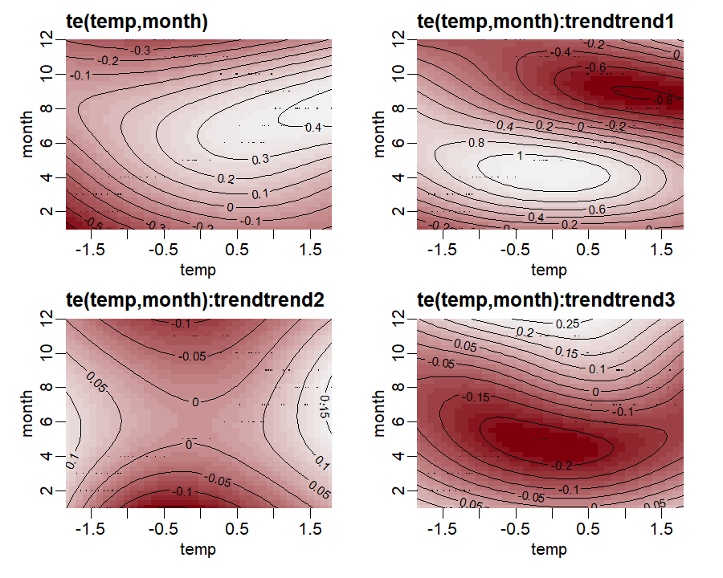

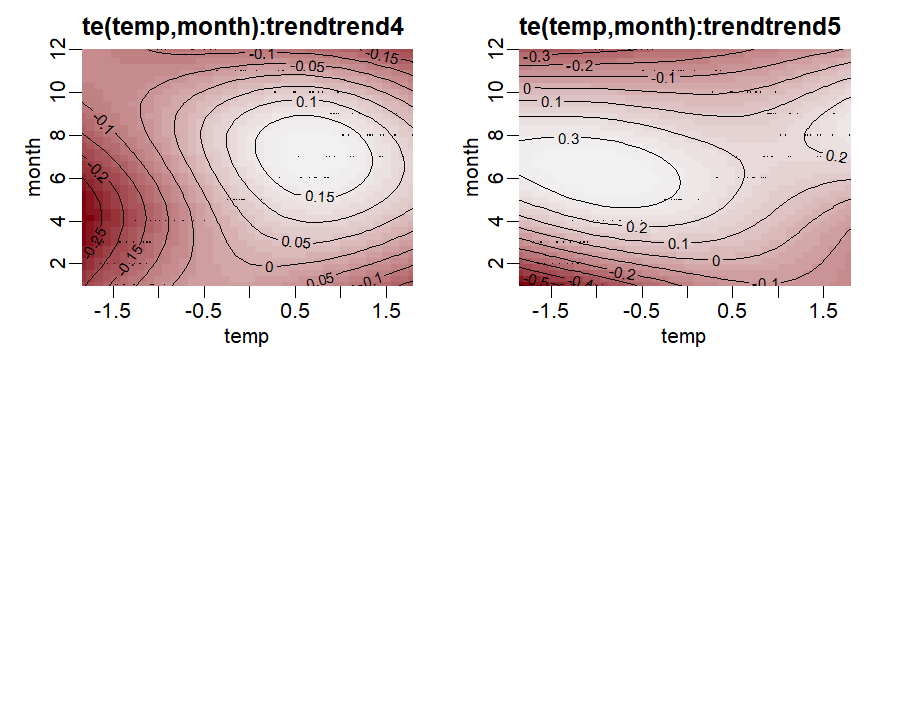

```r
plot(var_mod, 'smooths', trend_effects = TRUE)
```

The VAR matrix is of particular interest here, as it captures lagged dependencies and cross-dependencies in the latent process model:

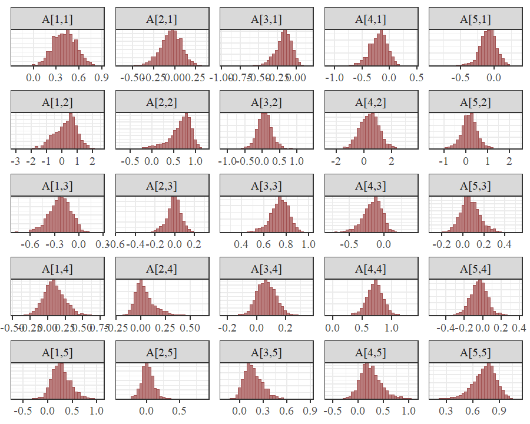

```r
mcmc_plot(var_mod, variable = 'A', regex = TRUE, type = 'hist')
```

Unfortunately `bayesplot` doesn’t know this is a matrix of parameters so what we see is actually the transpose of the VAR matrix. A little bit of wrangling gives us these histograms in the correct order:

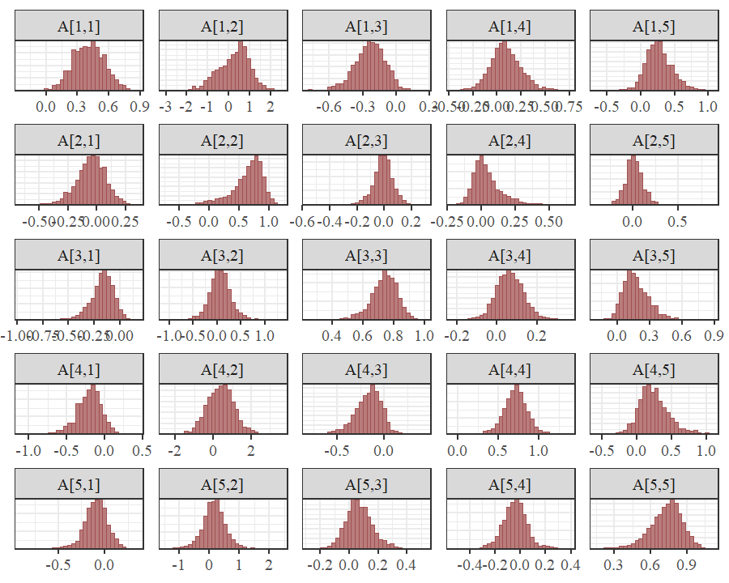

```r
A_pars <- matrix(NA, nrow = 5, ncol = 5)
for(i in 1:5){
  for(j in 1:5){
    A_pars[i, j] <- paste0('A[', i, ',', j, ']')
  }
}
mcmc_plot(var_mod,
          variable = as.vector(t(A_pars)),
          type = 'hist')
```

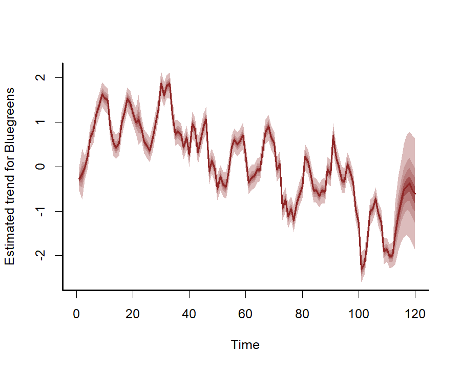

```r
plot(var_mod, type = 'trend', series = 1)
```

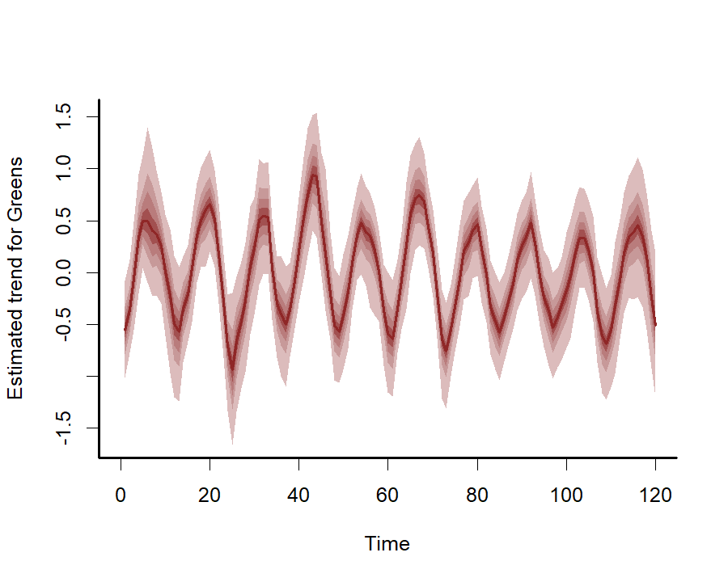

```r
plot(var_mod, type = 'trend', series = 3)
```

The process error $(\Sigma)$ captures unmodelled variation in the process models. Again, we fixed the off-diagonals to 0, so the histograms for these will look like flat boxes:

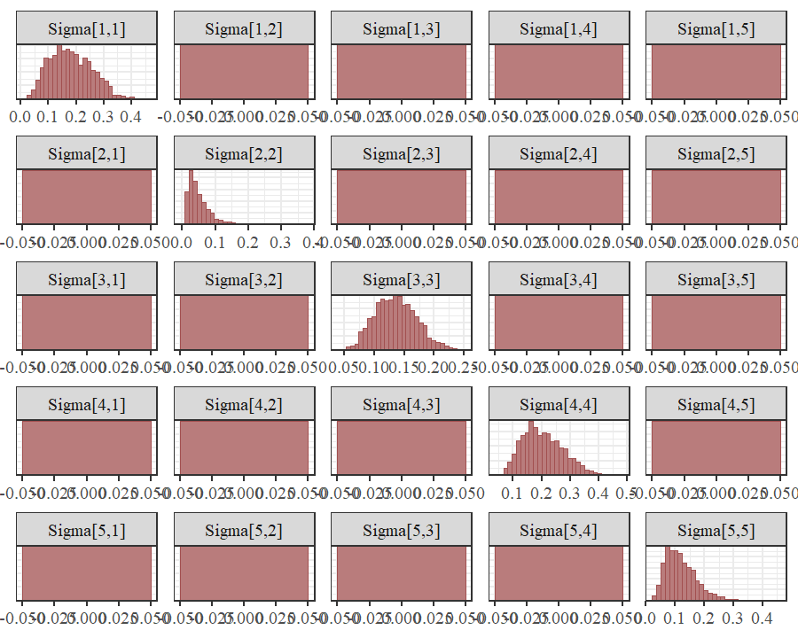

```r
Sigma_pars <- matrix(NA, nrow = 5, ncol = 5)
for(i in 1:5){
  for(j in 1:5){
    Sigma_pars[i, j] <- paste0('Sigma[', i, ',', j, ']')
  }
}
mcmc_plot(var_mod,
          variable = as.vector(t(Sigma_pars)),
          type = 'hist')
```

The observation error estimates $(\sigma_{obs})$ represent how much the model thinks we might miss the true count when we take our imperfect measurements:

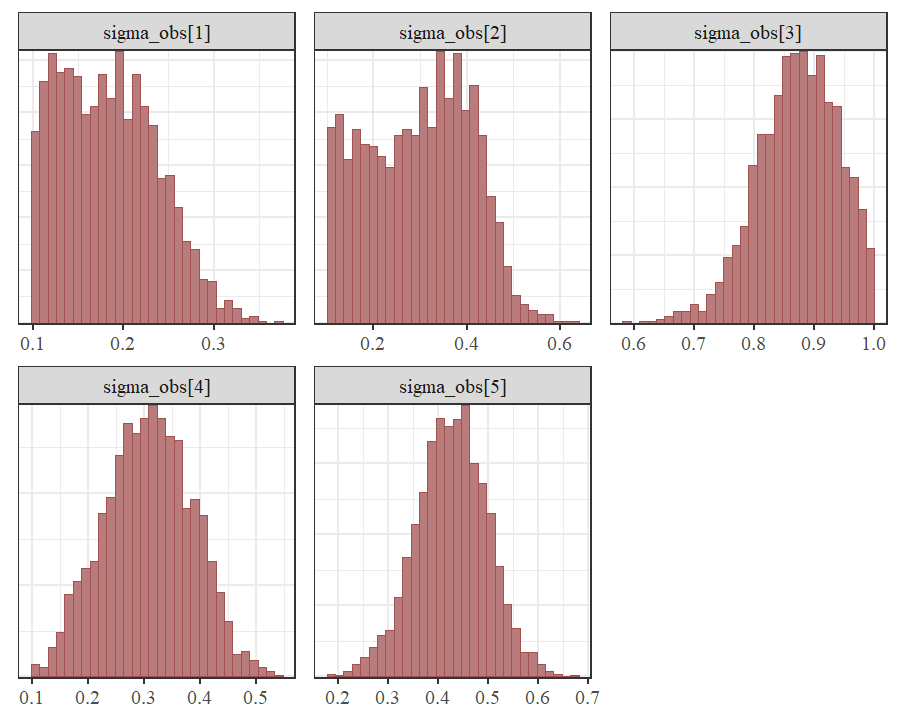

```r
mcmc_plot(var_mod, variable = 'sigma_obs', regex = TRUE, type = 'hist')
```

These are still a bit hard to identify overall.

### Correlated process errors

Let’s see if the estimates improve when we allow the process errors to be correlated. Once again, we need to first update the priors for the observation errors:

```r
priors <- get_mvgam_priors(
  # observation formula, which just uses an intercept
  y ~ 1,

  # process model formula, which includes the smooth functions
  trend_formula = ~ te(temp, month, k = c(4, 4)) +
    te(temp, month, k = c(4, 4), by = trend),

  # VAR1 model with correlated process errors
  trend_model = 'VAR1cor',
  family = gaussian(),
  data = plankton_train)

# update the sigma_obs prior so that it avoids very small
# and very large values that are nonsensical
priors$prior[11] <- "sigma_obs ~ uniform(0.1, 1);"
priors$new_lowerbound[11] <- 0.1
priors$new_upperbound[11] <- 1
```

And now we can fit the correlated process error model.

```r
varcor_mod <- mvgam(
  # observation formula, which just uses an intercept
  y ~ 1,

  # process model formula, which includes the smooth functions
  trend_formula = ~ te(temp, month, k = c(4, 4)) +
    te(temp, month, k = c(4, 4), by = trend),

  # VAR1 model with correlated process errors
  trend_model = 'VAR1cor',
  family = gaussian(),
  data = plankton_train,
  newdata = plankton_test,

  # include the updated priors
  priors = priors)
```

Plot convergence diagnostics for the two models, which shows that the more complex model with correlated errors has better convergence:

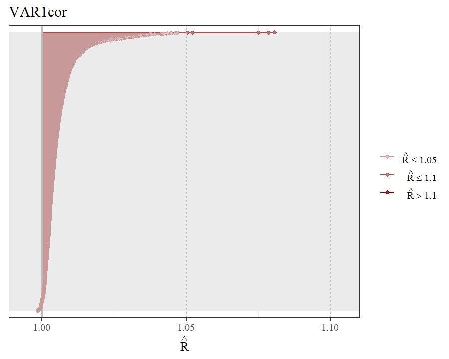

```r
mcmc_plot(varcor_mod, type = 'rhat') +
  labs(title = 'VAR1cor')
```

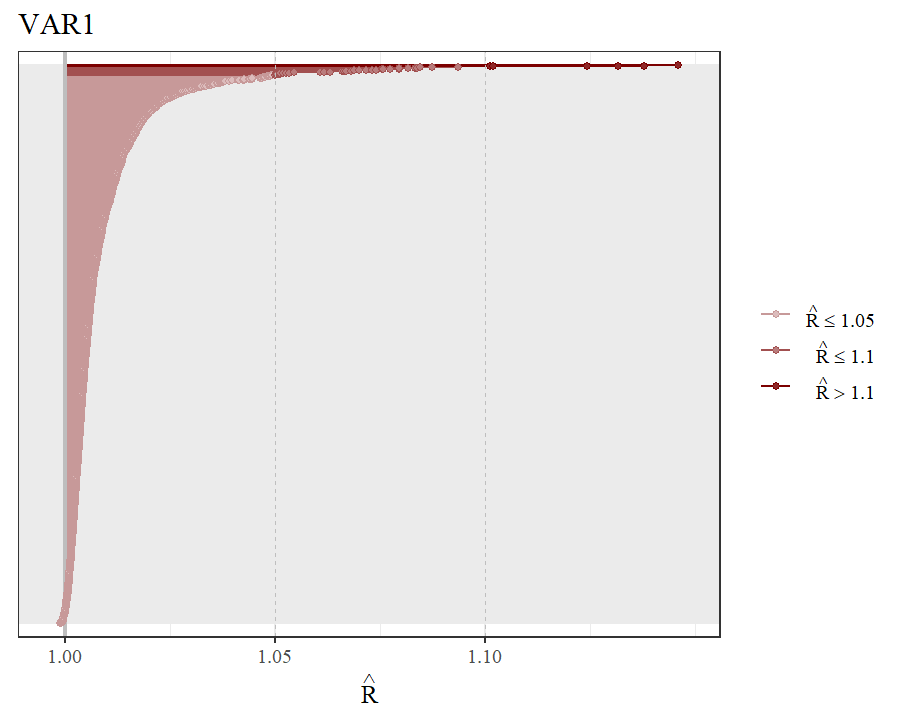

```r
mcmc_plot(var_mod, type = 'rhat') +
  labs(title = 'VAR1')
```

We can also check convergence using one of the package’s inbuilt utility functions:

```r
mvgam:::check_rhat(varcor_mod$model_output)
```

```
## Rhats above 1.05 found for 5 parameters
## *Diagnose further to investigate why the chains have not mixed
```